```python
from IPython.display import Image
```

# API - Theory

## API - Introduction

An API (Application Programming Interface) is a set of rules and methods through which an application or component interacts with others.

- E.x. Reading data from Twitter

## RESTful API

The most common type of API is a RESTful API.

**REST** stands for representational state transfer.

- More simply, this allows us to access data in presentable and convenient way
- REST represents an architecture

RESTful is an interpretation of REST.

- If a backend sever has a REST API and you make client side requests (e.x. from a website/app) to this API, then the client is RESTful

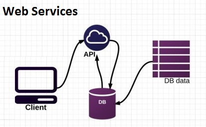

```python
Image('img/rest-api.jpg')
```

The above shows a REST architecture.

### How RESTful APIs Work

RESTful APIs generally have these four capabilities:

- **C**reate data
- **R**ead data
- **U**pdate data
- **D**elete data

This is also known as **CRUD** (create, read, update, delete).

REST relies heavily on **HTTP** (HyperText Transfer Protocol), which is an underlying protocol that defines how messages are formatted and transmitted across web servers.

Each CRUD operation has its own HTTP method:

- **POST** - Create
- **GET** - Read
- **PUT/PATCH** - Update
  - PUT updates the entire resource (overwrites the entire entity if it already exists, or creates a new resource if it doesn't)
  - PATCH applies a partial update
- **DELETE** - Delete

Each request made has an HTTP status code, which are split into 5 different classes. E.x. Error 404 is in class 4.

- **1xx** - Informational
- **2xx** - Success
- **3xx** - Redirect
- **4xx** - Client Error
- **5xx** - Server Error

## RESTful Calls

All resources in REST are entities. Generally methods are as: METHOD /ENTITY/ENTITY/ENTITY...

E.x.

- GET /users - gets all users
- GET /users/1 - gets user with id = 1
- GET /posts - gets all posts
  - These are all independent entities because they do not rely on any other entity
- GET /users/1/projects - gets projects associated with user id = 1
  - This is a dependent entity because it relies on a parent entity

The GET calls will return data.

What if we want to send data through the API?

- E.x. For POST

In the request body, define the parameters and send through as a POST request.

- POST /users

```python
# Example request body for a POST to /users
{
    "first_name": "Roary",
    "last_name": "Lion"
}
```

```
{'first_name': 'Roary', 'last_name': 'Lion'}
```

Sending this to POST /user will return a response with the data of the new entity

```python
{
    "id": "1",
    "first_name": "Roary",
    "last_name": "Lion"
}
```

```
{'first_name': 'Roary', 'id': '1', 'last_name': 'Lion'}
```

PUT/PATCH work in the same way as POST, except you must specify a user

e.x. PUT /users/1 will update user 1

DELETE is the same as PUT/PATCH

e.x. DELETE /users/1 will delete user 1

The response code you hope to get when doing these requests is 200 (OK).

## API Credentials

In order to do any API calls, many APIs will require you provide credentials. This is usually in the form of a client id and an API key, which allows you to "unlock" access to an API.

APIs from companies (e.x. Twitter, Yelp, Google) will especially use this to keep track of your usage. Depending on the level of usage, many companies will charge for their APIs. The client id and key is a way of keeping track of who you are and to what extent you have access to the APIs.

## Versioning

APIs get updated over time, it is important to make sure that you are referencing the version you want. There are two options for doing this:

- Indicate in the URL
  - E.x. http://example.com/api/v1
- Include a version in a request header

## JSON

It is standard for APIs to format data using **JSON** (Javascript Object Notation). JSON is basically a nested dictionary of entities.

E.x.

```python
x = '{"A":[1,2,3,{"B":24}]}' # Example of JSON object
x
```

```
'{"A":[1,2,3,{"B":24}]}'
```

This is more clearly written as:

```
{
"A": [
    1,
    2,
    3,
    {
    "B":24
    }
   ]
}
```

## Documentation

Pretty much all APIs will have its own set of documentation. This is what you should refer to understand how to utilize the API appropriately (e.x. "What kind of GET requests can I make?")

## More Resources

[More technical review of APIs](https://restfulapi.net/)